# R and Finance: Using Quantmod to better understand Stocks

# Charting Data

Quantmod allows you to use various charts to visualize any data that you load. The chartSeries function allows for very useful visualization in different forms, such as line charts, candle charts, and bar charts.

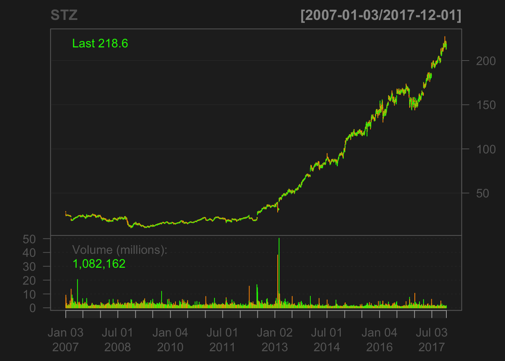

```r
barChart(STZ)
```

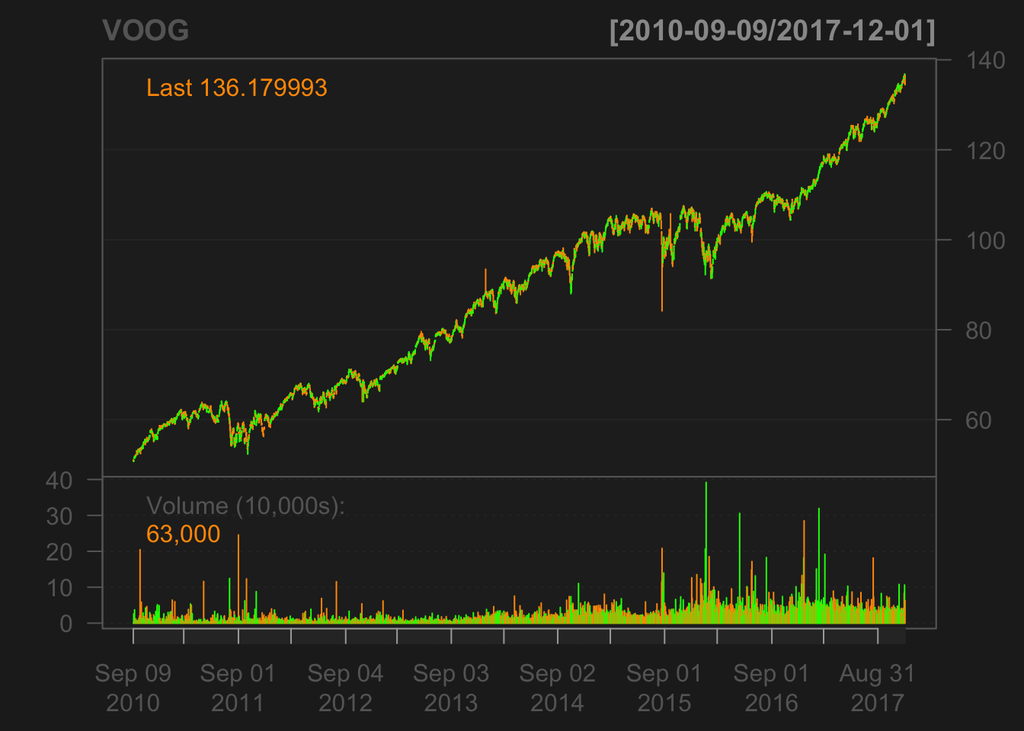

```r
barChart(VOOG)
```

The X-axis represents time, and the y-axis represents the stocks price. It also shows the volume of stock that was traded

We can select a certain variable and chart it. Here we will choose the volume of the Constellation Brand (STZ) stock.

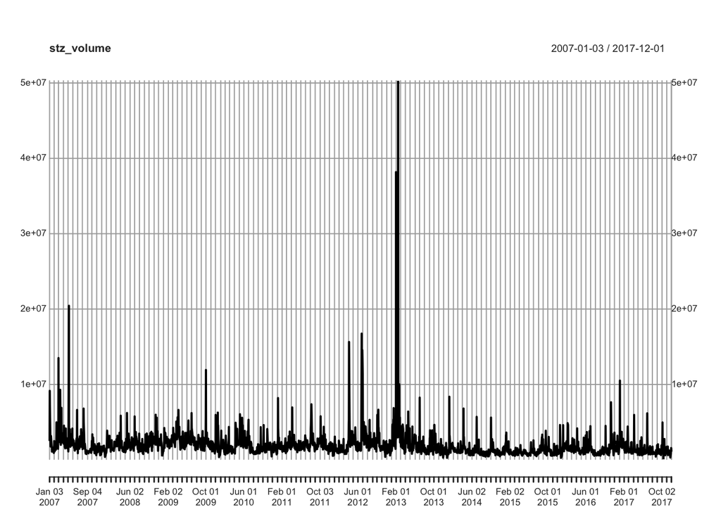

```r
#setting a variable to volume of STZ
stz_volume = Vo(STZ)
plot(stz_volume)
```

We can also use quantmod to add various technical indicators using the chartSeries function.

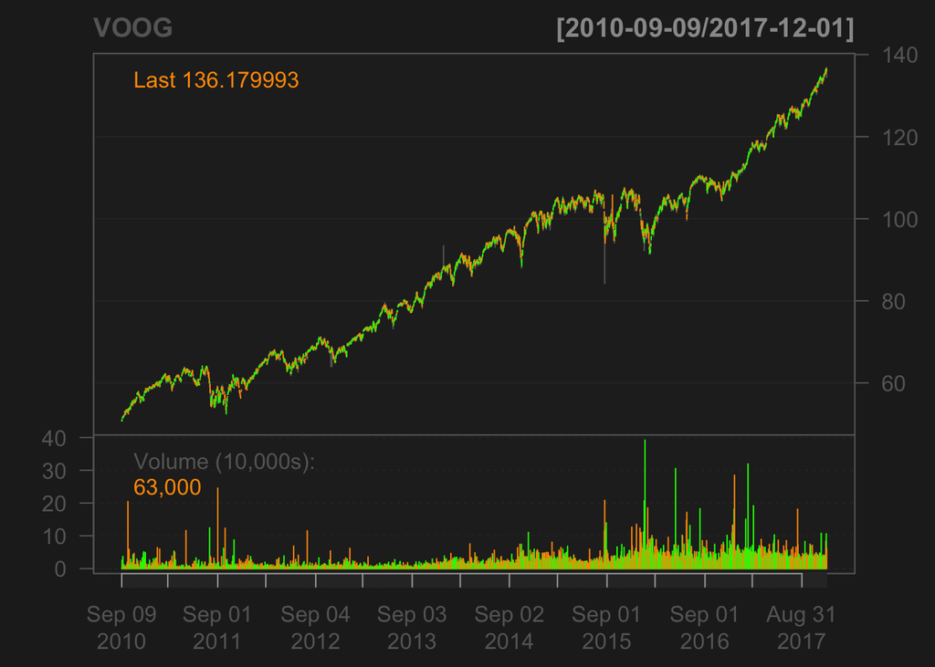

```r
chartSeries(VOOG) #load the chart
```